# **Introduction**

For this project, I chose to collect item listings from the Steam Community Market and use regression to predict their listing price based on the characteristics of each item. For reference, here is my Jupyter Notebook and the full dataset.

## The Steam Community Market

The Steam Community Market is a marketplace where users can sell collectible in-game items. When a seller sells an item, that item is transferred into the buyer's Steam inventory and the buyer's money is transferred into the seller's Steam Wallet.

## Items

While the Community Market supports the buying and selling of items from multiple games, the items I chose to examine are from Counter-Strike 2. Counter-Strike 2 has multiple types of items that can be sold on the Community Market, but I will be specifically examining one item type: weapon skins. Weapon skins can be applied to in-game weapons to change their visual appearance, but don't impact the gameplay attributes of weapons. For example, below is a weapon without a skin (left) and with a skin (right).

[figure not shown]

To obtain weapon skins, players can either open a weapon crate or purchase a specific skin from the Community Market. When opening a weapon crate, players exchange $2.50 for a random skin. Some skins are more rare than others, making them more valuable. Furthermore, weapon skins have various attributes that can affect their appearance and value in the Community Market. Any skin opened in a crate can be listed for sale on the Community Market. This creates what is essentially a micro-economy inside of the Community Market, where rare or otherwise appealing skins are sold on the Community Market for more than common or otherwise unappealing skins.

# **Data Collection**

## Scraping

I followed [an article by Dr. Blake Porter](https://www.blakeporterneuro.com/learning-python-project-3-scrapping-data-from-steams-community-market/) to scrape Steam Community Market data. This code can be used to scrape any number of items from any game with a Community Market presence.  
Since Steam only allows for 50 items to be retrieved at once, I used a loop to iterate through multiple pages automatically. However, Steam may reject a request at any time, so I needed to save the data at each iteration. The furthest I could get was 1,600 items before Steam rejected a request. I saved this data to a JSON and CSV file to be cleaned.

```python
#!pip install numpy pandas matplotlib seaborn
#!pip install sklearn
```

```python
import pandas as pd
import numpy as np
import seaborn as sns
import matplotlib.pyplot as plt
import json
import requests
import time
import random
```

```python
datapath = "./data"
```

```python
#https://www.blakeporterneuro.com/learning-python-project-3-scrapping-data-from-steams-community-market/

all_items = []
item_count = 2000

for i in range(0,item_count+50,50):
    time.sleep(random.uniform(2.5, 5.0))

    # Makes request starting starting from the current iteration
    response = requests.get(
        url='https://steamcommunity.com/market/search/render/?start='+
        str(i)+'&count=100&search_descriptions=0&sort_column=default&sort_dir=desc&appid=730&norender=1&count=5000',
        params={'json':1},
        headers={'User-Agent': 'Mozilla/5.0'}
    )

    # Save response to a list
    items = json.loads(response.content)
    items = items['results']
    for i in items:
        all_items.append(i)

    # Writing on each iteration in order to preserve previous data if Steam refuses a request
    with open(datapath+"/data.json", 'w') as f:
        json.dump(all_items, f)
```

```python
data = json.load(open(datapath+"/data.json"))
df = pd.DataFrame(data)
df.to_csv(datapath+"/data.csv")
df.head()
```

|  | name | hash_name | sell_listings | sell_price | sell_price_text | app_icon | app_name | asset_description | sale_price_text |
| --- | --- | --- | --- | --- | --- | --- | --- | --- | --- |
| 0 | Souvenir Nova \| Green Apple (Factory New) | Souvenir Nova \| Green Apple (Factory New) | 96 | 904 | $9.04 | https://cdn.akamai.steamstatic.com/steamcommun... | Counter-Strike 2 | {'appid': 730, 'classid': '5765247964', 'insta... | $8.65 |
| 1 | AK-47 \| Black Laminate (Battle-Scarred) | AK-47 \| Black Laminate (Battle-Scarred) | 32 | 2945 | $29.45 | https://cdn.akamai.steamstatic.com/steamcommun... | Counter-Strike 2 | {'appid': 730, 'classid': '5768111848', 'insta... | $28.17 |
| 2 | SCAR-20 \| Cardiac (Field-Tested) | SCAR-20 \| Cardiac (Field-Tested) | 130 | 361 | $3.61 | https://cdn.akamai.steamstatic.com/steamcommun... | Counter-Strike 2 | {'appid': 730, 'classid': '638243033', 'instan... | $3.46 |
| 3 | P2000 \| Coach Class (Minimal Wear) | P2000 \| Coach Class (Minimal Wear) | 27 | 1243 | $12.43 | https://cdn.akamai.steamstatic.com/steamcommun... | Counter-Strike 2 | {'appid': 730, 'classid': '519984386', 'instan... | $11.89 |
| 4 | StatTrak™ MAG-7 \| Memento (Minimal Wear) | StatTrak™ MAG-7 \| Memento (Minimal Wear) | 132 | 502 | $5.02 | https://cdn.akamai.steamstatic.com/steamcommun... | Counter-Strike 2 | {'appid': 730, 'classid': '5770966536', 'insta... | $4.81 |

# **Data Cleaning**

## Removing Unnecessary Fields

The first step of the cleaning process was removing unnecessary fields from each item's data. I removed fields that were duplicates of other fields (such as has_name), fields that shared values between all items (such as app_id which indicates the game that the item is used in), and other fields that would not affect the listing price of the item.

```python
df_clean = df.drop(["app_name"], axis=1)
df_clean = df_clean.drop(["app_icon"], axis=1)
df_clean = df_clean.drop(["asset_description"], axis=1)
df_clean = df_clean.drop(["hash_name"], axis=1)
df_clean = df_clean.drop(["sell_price_text"], axis=1)
df_clean = df_clean.drop(["sale_price_text"], axis=1)

price_conversion = []
for i in range(0, len(df_clean["sell_price"])):
    price_conversion.append(0)
    price_conversion[i] = df_clean["sell_price"][i] / 100

df_clean = df_clean.drop(["sell_price"], axis=1)
df_clean.insert(2, "sell_price", price_conversion, True)

df_clean.head()
```

|  | name | sell_listings | sell_price |
| --- | --- | --- | --- |
| 0 | Souvenir Nova \| Green Apple (Factory New) | 96 | 9.04 |
| 1 | AK-47 \| Black Laminate (Battle-Scarred) | 32 | 29.45 |
| 2 | SCAR-20 \| Cardiac (Field-Tested) | 130 | 3.61 |
| 3 | P2000 \| Coach Class (Minimal Wear) | 27 | 12.43 |
| 4 | StatTrak™ MAG-7 \| Memento (Minimal Wear) | 132 | 5.02 |

## Extracting Fields

Some of the fields I was interested in were included in the "name" column. For example, the "StatTrak" attribute is an uncommon attribute for skins to possess. However, the StatTrak attribute in the data is not given its own field but instead is included in the name of the item. To extract this field, and other fields like it, I needed to use language processing techniques.

### Souvenir

Souvenir skins are items that have one or more professional players' signatures included on them. These signatures can be bought separately and applied to skins. For each item containing the string "Souvenir" in its name, I set their "is_souvenir" field to 1.

```python
temp_names = df_clean["name"].copy()
souvenir = []
for i in range(0, len(temp_names)):
    souvenir.append("0")
    temp_names[i] = temp_names[i].split("Souvenir")
    if temp_names[i][0] == "":
        souvenir[i] = "1"
```

```python
df_clean.insert(1, "is_souvenir", souvenir, True)
df_clean.head()
```

|  | name | is_souvenir | sell_listings | sell_price |
| --- | --- | --- | --- | --- |
| 0 | Souvenir Nova \| Green Apple (Factory New) | 1 | 96 | 9.04 |
| 1 | AK-47 \| Black Laminate (Battle-Scarred) | 0 | 32 | 29.45 |
| 2 | SCAR-20 \| Cardiac (Field-Tested) | 0 | 130 | 3.61 |
| 3 | P2000 \| Coach Class (Minimal Wear) | 0 | 27 | 12.43 |
| 4 | StatTrak™ MAG-7 \| Memento (Minimal Wear) | 0 | 132 | 5.02 |

### StatTrak

StatTrak skins are items that count the number of kills that a player gets with said skin equipped. This variation of skin is uncommon. I approached this field extraction in the exact same way as the Souvenir field.

```python
temp_names = df_clean["name"].copy()
stat_trak = []
for i in range(0, len(temp_names)):
    stat_trak.append("0")
    temp_names[i] = temp_names[i].split("StatTrak™")
    if temp_names[i][0] == "":
        stat_trak[i] = "1"
```

```python
df_clean.insert(1, "is_stat_trak", stat_trak, True)
df_clean.head()
```

|  | name | is_stat_trak | is_souvenir | sell_listings | sell_price |
| --- | --- | --- | --- | --- | --- |
| 0 | Souvenir Nova \| Green Apple (Factory New) | 0 | 1 | 96 | 9.04 |
| 1 | AK-47 \| Black Laminate (Battle-Scarred) | 0 | 0 | 32 | 29.45 |
| 2 | SCAR-20 \| Cardiac (Field-Tested) | 0 | 0 | 130 | 3.61 |
| 3 | P2000 \| Coach Class (Minimal Wear) | 0 | 0 | 27 | 12.43 |
| 4 | StatTrak™ MAG-7 \| Memento (Minimal Wear) | 1 | 0 | 132 | 5.02 |

### Wear Rating

Wear rating is a random attribute that is different for every individual item. Items with a high wear rating have a more worn appearance to them. For example, below is the same skin with different wear ratings. The left shows an item that is very worn while the left shows an item with the same skin but with low wear.

[figure not shown]

```python
import re
```

```python
temp_names = df_clean["name"].copy()
wear_rating = []
for i in range(0, len(temp_names)):
    wear_rating.append("")
    search = re.search('\(([^)]+)', temp_names[i])
    if search:
        wear_rating[i] = search.group(1)

wear_rating_num = []
for i in range(0, len(wear_rating)):
    wear_rating_num.append(0)
    if wear_rating[i] == "Factory New":
        wear_rating_num[i] = 5
    elif wear_rating[i] == "Minimal Wear":
        wear_rating_num[i] = 4
    elif wear_rating[i] == "Field-Tested":
        wear_rating_num[i] = 3
    elif wear_rating[i] == "Well-Worn":
        wear_rating_num[i] = 2
    elif wear_rating[i] == "Battle-Scarred":
        wear_rating_num[i] = 1
```

```python
df_clean.insert(1, "wear_rating_num", wear_rating_num, True)
df_clean.insert(1, "wear_rating", wear_rating, True)
df_clean.head()
```

|  | name | wear_rating | wear_rating_num | is_stat_trak | is_souvenir | sell_listings | sell_price |
| --- | --- | --- | --- | --- | --- | --- | --- |
| 0 | Souvenir Nova \| Green Apple (Factory New) | Factory New | 5 | 0 | 1 | 96 | 9.04 |
| 1 | AK-47 \| Black Laminate (Battle-Scarred) | Battle-Scarred | 1 | 0 | 0 | 32 | 29.45 |
| 2 | SCAR-20 \| Cardiac (Field-Tested) | Field-Tested | 3 | 0 | 0 | 130 | 3.61 |
| 3 | P2000 \| Coach Class (Minimal Wear) | Minimal Wear | 4 | 0 | 0 | 27 | 12.43 |
| 4 | StatTrak™ MAG-7 \| Memento (Minimal Wear) | Minimal Wear | 4 | 1 | 0 | 132 | 5.02 |

```python
print(len(df_clean))
df_clean = df_clean[df_clean.wear_rating_num != 0] # Remove non-weapon items
print(len(df_clean))
```

```
1600
1544
```

# **Data Exploration**

After cleaning and collecting the data, I used different graphs to illustrate relationships between each variable and sell_price. The most noticeable relationships were present on the first scatterplot and the boxplot. The first scatterplot shows that, in general, items with more listings are worth less. This suggests that scarcity plays a role in the value of items. The boxplot shows that skins with less wear (represented by a higher wear_rating_num) are generally more valuable. Finally, I used a heatmap to illustrate how different variables may be correlated. However, most variables seemed to be fairly independent. The variables most associated with sell_price were wear_rating_num and sell_listings, which reflects the conclusions I determined from the graphs.

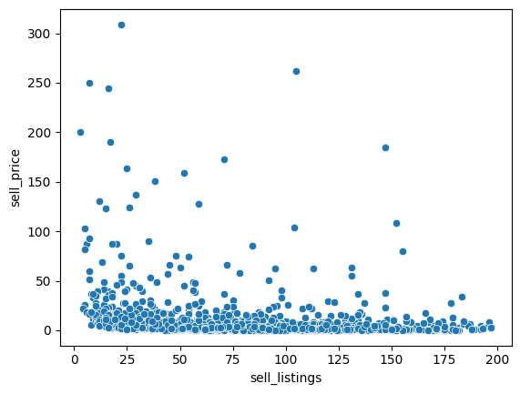

```python
scatter = sns.scatterplot(data=df_clean, x='sell_listings', y='sell_price')
plt.show()
```

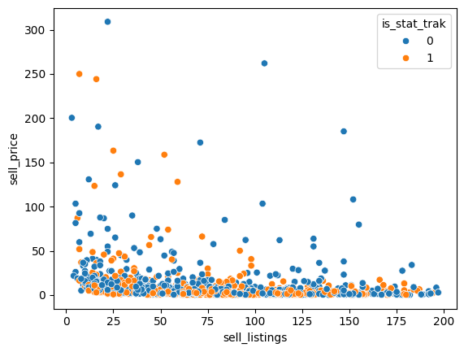

```python
scatter = sns.scatterplot(data=df_clean, x='sell_listings', y='sell_price', hue='is_stat_trak')
plt.show()
```

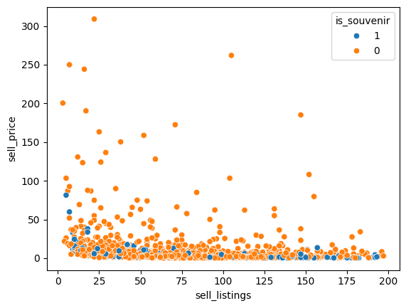

```python
scatter = sns.scatterplot(data=df_clean, x='sell_listings', y='sell_price', hue='is_souvenir')
plt.show()
```

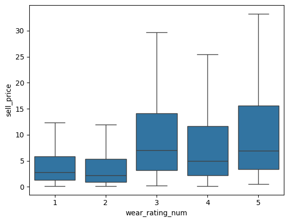

```python
fig = sns.boxplot(x="wear_rating_num", y="sell_price", data=df_clean, showfliers=False)
plt.show()
```

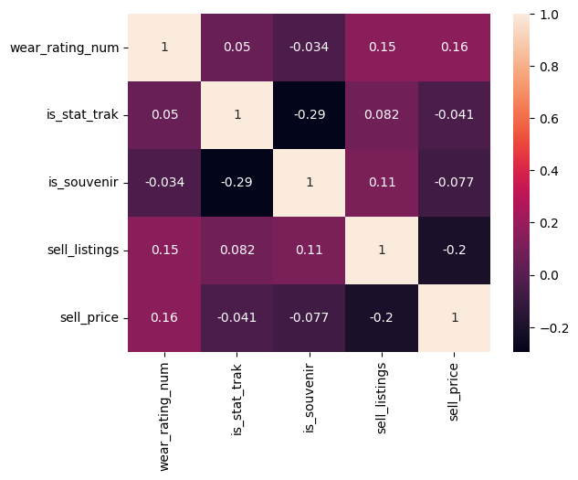

```python
df_test = df_clean.copy()
df_test = df_test.drop(["wear_rating"], axis=1)
df_test = df_test.drop(["name"], axis=1)

sns.heatmap(df_test.corr(),annot = True)
```

# **Experiment 1**

## Modeling

In my first experiment, I trained a linear regression model to predict the sell_price of items based on their number of listings (sell_listings).

```python
from sklearn import preprocessing, svm
from sklearn.model_selection import train_test_split
from sklearn.linear_model import LinearRegression
```

```python
X = np.array(df_clean['sell_listings']).reshape(-1, 1)
y = np.array(df_clean['sell_price']).reshape(-1, 1)

X_train, X_test, y_train, y_test = train_test_split(X, y, test_size = 0.25)

regr = LinearRegression()

regr.fit(X_train, y_train)
y_pred = regr.predict(X_test)
for i in range(0, 10):
    print("Actual Price:", y_test[i], "Predicted Price:", y_pred[i])
```

```
Actual Price: [6.] Predicted Price: [14.35086091]
Actual Price: [0.32] Predicted Price: [15.56676747]
Actual Price: [3.1] Predicted Price: [7.05542154]
Actual Price: [2.] Predicted Price: [15.23515659]
Actual Price: [6.22] Predicted Price: [6.94488458]
Actual Price: [0.63] Predicted Price: [8.16079114]
Actual Price: [5.25] Predicted Price: [17.33535883]
Actual Price: [5.55] Predicted Price: [14.79300875]
Actual Price: [3.05] Predicted Price: [18.10911756]
Actual Price: [9.21] Predicted Price: [17.00374795]
```

## Evaluation

I used RMSE and R2 scoring to evaluate the model. This model scored particularly poorly in each evaluation. To find which items were causing the model to struggle, I created a scatterplot of the actual vs. predicted sell_price. The scatterplot illustrates how items with an extremely high sell_price are not well-represented.  
The scatterplot proved to be very useful, so I continued to use it as a secondary means of evaluation, where a dense positive correlation between the variables represents a well-preforming model.

```python
from sklearn.metrics import root_mean_squared_error, r2_score
print(root_mean_squared_error(y_test, y_pred))
print(r2_score(y_test, y_pred))
```

```
19.580372596226564
0.06765630522976496
```

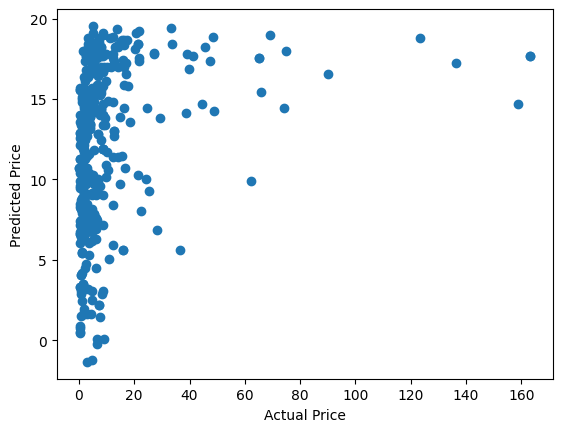

```python
plt.scatter(y_test, y_pred)
plt.xlabel('Actual Price')
plt.ylabel('Predicted Price')
```

# **Experiment 2**

## Modeling

To address the main issue from Experiment 1, I decided to remove outliers from the dataset. I removed any item with a sell_price higher than $30.00. This only removed about 100 items from the dataset but showed significant improvements in the RMSE evaluation.

```python
print(len(df_clean))
df_clean2 = df_clean[df_clean.sell_price <= 30.00]
print(len(df_clean2))
```

```
1544
1431
```

```python
X = np.array(df_clean2['sell_listings']).reshape(-1, 1)
y = np.array(df_clean2['sell_price']).reshape(-1, 1)

X_train, X_test, y_train, y_test = train_test_split(X, y, test_size = 0.25)

regr = LinearRegression()

regr.fit(X_train, y_train)
y_pred = regr.predict(X_test)
for i in range(0, 10):
    print("Actual Price:", y_test[i], "Predicted Price:", y_pred[i], "Listings:", X_test[i])
```

```
Actual Price: [17.31] Predicted Price: [9.04565102] Listings: [21]
Actual Price: [0.7] Predicted Price: [6.76556863] Listings: [67]
Actual Price: [3.15] Predicted Price: [5.4272594] Listings: [94]
Actual Price: [29.74] Predicted Price: [4.13851717] Listings: [120]
Actual Price: [17.43] Predicted Price: [9.29348606] Listings: [16]
Actual Price: [1.35] Predicted Price: [3.44457905] Listings: [134]
Actual Price: [0.69] Predicted Price: [6.07163051] Listings: [81]
Actual Price: [9.11] Predicted Price: [7.36037273] Listings: [55]
Actual Price: [1.75] Predicted Price: [6.26989854] Listings: [77]
Actual Price: [13.87] Predicted Price: [9.59088811] Listings: [10]
```

## Evaluation

While the R2 score didn't improve, both the RMSE and scatterplot show that removing outliers had a significant impact on the performance of the model. However, the model still seemed to struggle quite a bit.

```python
print(root_mean_squared_error(y_test, y_pred))
print(r2_score(y_test, y_pred))
```

```
5.730420209315442
0.005107229019209347
```

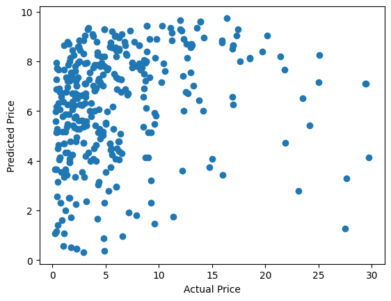

```python
plt.scatter(y_test, y_pred)
plt.xlabel('Actual Price')
plt.ylabel('Predicted Price')
```

# **Experiment 3**

## Modeling

I decided to try a different regression model in Experiment 3. I used a polynomial regression model in an attempt to more accurately represent a relationship between the sell_price and sell_listings.

```python
from sklearn.preprocessing import PolynomialFeatures
from sklearn.pipeline import make_pipeline

pipeline = make_pipeline(PolynomialFeatures(2), LinearRegression())

X = np.array(df_clean2['sell_listings']).reshape(-1, 1)
y = np.array(df_clean2['sell_price']).reshape(-1, 1)

X_train, X_test, y_train, y_test = train_test_split(X, y, test_size = 0.25)

pipeline.fit(X_train, y_train)
y_pred = pipeline.predict(X_test)
for i in range(0, 10):
    print("Actual Price:", y_test[i], "Predicted Price:", y_pred[i], "Listings:", X_test[i])
```

```
Actual Price: [15.23] Predicted Price: [10.42895712] Listings: [17]
Actual Price: [3.76] Predicted Price: [7.49463493] Listings: [43]
Actual Price: [20.93] Predicted Price: [6.5038742] Listings: [54]
Actual Price: [1.15] Predicted Price: [3.70098022] Listings: [117]
Actual Price: [13.] Predicted Price: [10.04788236] Listings: [20]
Actual Price: [11.78] Predicted Price: [6.10280277] Listings: [59]
Actual Price: [0.39] Predicted Price: [5.66216839] Listings: [65]
Actual Price: [27.2] Predicted Price: [9.55702869] Listings: [24]
Actual Price: [5.02] Predicted Price: [3.75426193] Listings: [132]
Actual Price: [2.21] Predicted Price: [5.08436729] Listings: [74]
```

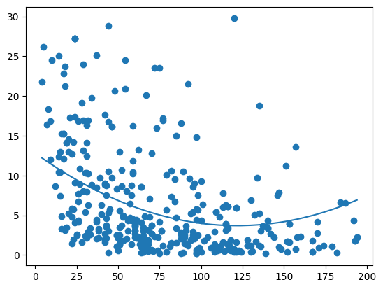

```python
plt.scatter(X_test, y_test)
plt.plot(sorted(X_test), pipeline.predict(sorted(X_test)))
```

## Evaluation

This model performed significantly better than the linear model regarding the R2 score. Looking at the scatterplot, the predicted price has a much stronger correlation to the actual price.

```python
print(root_mean_squared_error(y_test, y_pred))
print(r2_score(y_test, y_pred))
```

```
5.784432816974394
0.20515201860945687
```

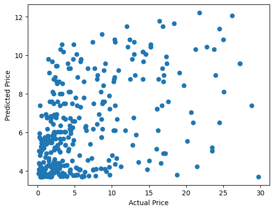

```python
plt.scatter(y_test, y_pred)
plt.xlabel('Actual Price')
plt.ylabel('Predicted Price')
```

# **Experiment 4**

## Modeling

After settling on a better regression model in Experiment 3, I decided to include the remaining features in Experiment 4.

```python
from sklearn.preprocessing import PolynomialFeatures
from sklearn.pipeline import make_pipeline

pipeline = make_pipeline(PolynomialFeatures(2), LinearRegression())

X = np.array(df_clean2[['sell_listings', 'wear_rating_num', 'is_souvenir', 'is_stat_trak']]).reshape(-1, 4)
y = np.array(df_clean2['sell_price']).reshape(-1, 1)

X_train, X_test, y_train, y_test = train_test_split(X, y, test_size = 0.25)

pipeline.fit(X_train, y_train)
y_pred = pipeline.predict(X_test)
for i in range(0, 10):
    print("Actual Price:", y_test[i], "Predicted Price:", y_pred[i], "Listings, Wear Rating, Souvenir, StatTrak:", X_test[i])
```

```
Actual Price: [0.32] Predicted Price: [3.93001801] Listings, Wear Rating, Souvenir, StatTrak: [62 2 '0' '1']
Actual Price: [10.46] Predicted Price: [5.45849306] Listings, Wear Rating, Souvenir, StatTrak: [89 5 '0' '1']
Actual Price: [1.68] Predicted Price: [5.24428286] Listings, Wear Rating, Souvenir, StatTrak: [156 1 '0' '0']
Actual Price: [12.53] Predicted Price: [6.59710682] Listings, Wear Rating, Souvenir, StatTrak: [67 3 '0' '0']
Actual Price: [0.27] Predicted Price: [4.2903321] Listings, Wear Rating, Souvenir, StatTrak: [89 2 '0' '0']
Actual Price: [7.14] Predicted Price: [7.66188568] Listings, Wear Rating, Souvenir, StatTrak: [165 5 '0' '0']
Actual Price: [0.98] Predicted Price: [3.26273625] Listings, Wear Rating, Souvenir, StatTrak: [99 3 '0' '1']
Actual Price: [16.85] Predicted Price: [7.8089632] Listings, Wear Rating, Souvenir, StatTrak: [75 5 '0' '0']
Actual Price: [3.4] Predicted Price: [1.80263315] Listings, Wear Rating, Souvenir, StatTrak: [116 3 '1' '0']
Actual Price: [25.02] Predicted Price: [13.29417885] Listings, Wear Rating, Souvenir, StatTrak: [14 3 '1' '0']
```

## Evaluation

Due to having more data to work with, the model performed better by all evaluations in this experiment.

```python
print(root_mean_squared_error(y_test, y_pred))
print(r2_score(y_test, y_pred))
```

```
4.94091741673364
0.3000628613274725
```

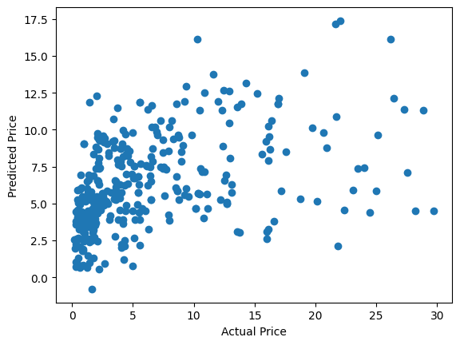

```python
plt.scatter(y_test, y_pred)
plt.xlabel('Actual Price')
plt.ylabel('Predicted Price')
```

# **Conclusion**

## Results

While the final model didn't perform very accurately, I am happy with how much I was able to improve the models through experimentation. Each experiment revealed a different way in which each model was struggling, and I enjoyed figuring out how to target each weakness.  
I think that the model needs more impactful features to improve further. For example, I suspect that the weapon finish and weapon model have a big impact on the price of items, but I didn't include these features in this project. Since these features cannot be numerically represented, I would have to use one-hot encoding to use them in the model.

## Impact

While I find the Steam Community Market very interesting, I think that the effects the system has on the player base is overall negative. Skins can be opened from crates for $2.50 and sold on the Community Market for real money. Since opening crates gives players a random skin, there is a small chance that they can get a very rare skin. Since these skins can be sold on the Community Market for real money, skins have tangible value. Therefore, the system essentially creates an economy based on gambling. While I don't inherently have a problem with gambling, many players are children and teenagers, so this system essentially allows for underage gambling. I find this to be highly unethical and believe that Valve (the developers of both Counter-Strike and Steam) needs to take action to prevent children from participating in the opening, selling, and trading of skins.  
That being said, my project's utility in the skins market is limited at best. However, if it were to be improved, it could be used by buyers and sellers to predict the price of certain items based on their specific features. Again, I don't inherently have a problem with this use case, but I don't like the idea of contributing to a system that allows for underage gambling.

## References

Data Collection: https://www.blakeporterneuro.com/learning-python-project-3-scrapping-data-from-steams-community-market/

Linear Regression: https://www.geeksforgeeks.org/python-linear-regression-using-sklearn/  
Polynomial Regression: https://www.youtube.com/watch?v=e4c_UP2fSjg&t=123s